# Comparing Universities

```python
%matplotlib inline
```

```python
from __future__ import division
```

```python
import numpy as np
import scipy.stats as stats
import seaborn as sns
import matplotlib.pyplot as plt
import pandas as pd
import patsy
import sklearn.linear_model as linear
import random

sns.set(style="darkgrid")
```

*University with program length 4 year or higher*

```python
data = pd.read_csv('College.csv')
data.info()
```

```
<class 'pandas.core.frame.DataFrame'>
RangeIndex: 777 entries, 0 to 776
Data columns (total 19 columns):
University Name    777 non-null object
Private            777 non-null object
Apps               777 non-null int64
Accept             777 non-null int64
Enroll             777 non-null int64
Top10perc          777 non-null int64
Top25perc          777 non-null int64
F.Undergrad        777 non-null int64
P.Undergrad        777 non-null int64
Outstate           777 non-null int64
Room.Board         777 non-null int64
Books              777 non-null int64
Personal           777 non-null int64
PhD                777 non-null int64
Terminal           777 non-null int64
S.F.Ratio          777 non-null float64
perc.alumni        777 non-null int64
Expend             777 non-null int64
Grad.Rate          777 non-null int64
dtypes: float64(1), int64(16), object(2)
memory usage: 115.4+ KB
```

Additional Info : [• **Private** : Public/private indicator • **Apps** : Number of applications received • **Accept** : Number of applicants accepted • **Enroll** : Number of new students enrolled • **Top10perc** : New students from top 10% of high school class • **Top25perc** : New students from top 25% of high school class • **F.Undergrad** : Number of full-time undergraduates • **P.Undergrad** : Number of part-time undergraduates • **Outstate** : Out-of-state tuition • **Room.Board** : Room and board costs • **Books** : Estimated book costs • **Personal** : Estimated personal spending • **PhD** : Percent of faculty with Ph.D.’s • **Terminal** : Percent of faculty with terminal degree • **S.F.Ratio** : Student/faculty ratio • **perc.alumni** : Percent of alumni who donate • **Expend** : Instructional expenditure per student • **Grad.Rate** : Graduation rate ]

```python
# Replacing the numeric gender values with label

# Replace
data['Private'].replace( 'Yes','Private',inplace=True)
data['Private'].replace('No','Public',inplace=True)
```

```python
data.Private.value_counts()
```

```
Private    565
Public     212
Name: Private, dtype: int64
```

```python
data.Private.value_counts()
```

```
Private    565
Public     212
Name: Private, dtype: int64
```

```python
acceptance_pct = (data['Accept']/data['Apps'])*100
```

```python
data['Acceptance_Percent'] = acceptance_pct
```

# Are the acceptance rates of private and non private universities positively co related?

```python
Public_Acceptance_Rate= []
Private_Acceptance_Rate= []

for each in data.index:
    if data['Private'][each] == 'Private':
        Private_Acceptance_Rate.append(data['Acceptance_Percent'][each])
    else:
        Public_Acceptance_Rate.append(data['Acceptance_Percent'][each])
```

```python
stats.spearmanr( Private_Acceptance_Rate[:200], Public_Acceptance_Rate[:200])[ 0]
```

```
-0.040888848887839745
```

```python
x = Private_Acceptance_Rate[:200]
y = Public_Acceptance_Rate[:200]
def scatter_plot_with_correlation_line(x, y):
    '''
    http://stackoverflow.com/a/34571821/395857
    x does not have to be ordered.
    '''
    # Scatter plot
    plt.scatter(x, y)

    # Add correlation line
    axes = plt.gca()
    m, b = np.polyfit(x, y, 1)
    X_plot = np.linspace(axes.get_xlim()[0],axes.get_xlim()[1],100)
    plt.plot(X_plot, m*X_plot + b, '-')
    axes.set_xlabel('Private_Acceptance_Rate')
    axes.set_ylabel('Public_Acceptance_Rate')


    # Save figure
   # plt.savefig(graph_filepath, dpi=300, format='png', bbox_inches='tight')

def main():
    # Data
    x = np.random.rand(100)
    y = x + np.random.rand(100)*0.1

    # Plot
    scatter_plot_with_correlation_line(x, y)
```

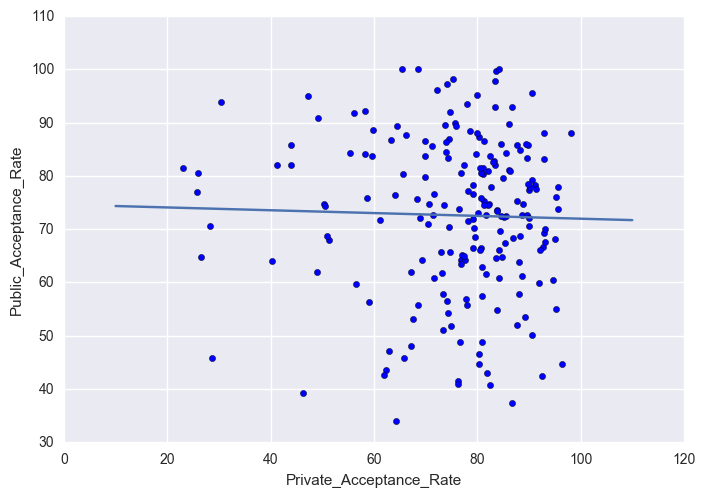

```python
scatter_plot_with_correlation_line(x,y)
```

No, they are not they are negatively corelated and the corelation coefficient is weak

**University offering at least 4 year or higher degree**

*Avg expenditure of Private University where incoming class has students (top 10% of high school more than 70 pc)*

```python
Private_School_Cost = []
for each in data.index:
    if (data['Top10perc'][each] >= 70 and data['Private'][each] == 'Private'):
        Private_School_Cost.append(data['Outstate'][each])
```

*University offering at least 4 year or higher degree Avg expenditure of Public University where incoming class has students (top 10% of high school more than 70 pc)*

```python
Public_School_Cost = []
for each in data.index:
    if (data['Top10perc'][each] >= 70 and data['Private'][each] == 'Public'):
        Public_School_Cost.append(data['Outstate'][each])
```

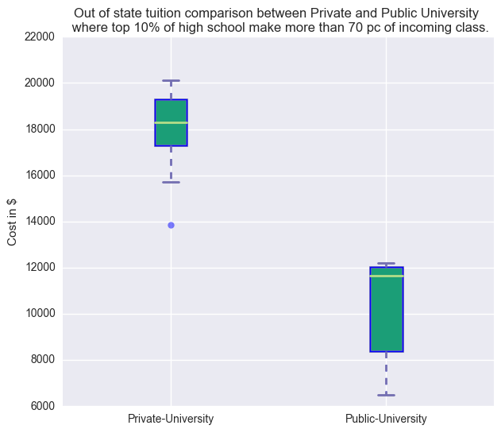

```python
# Code from http://blog.bharatbhole.com/creating-boxplots-with-matplotlib/
## combine these different collections into a list
data_to_plot = [Private_School_Cost, Public_School_Cost]
# Create a figure instance
fig = plt.figure(1, figsize=(7, 6))

# Create an axes instance
ax = fig.add_subplot(111)

# Create the boxplot
bp = ax.boxplot(data_to_plot)

fig.savefig('fig1.png', bbox_inches='tight')

## add patch_artist=True option to ax.boxplot()
## to get fill color
bp = ax.boxplot(data_to_plot, patch_artist=True)

## change outline color, fill color and linewidth of the boxes
for box in bp['boxes']:
    # change outline color
    box.set( color='#7570b3', linewidth=2)
    # change fill color
    box.set( facecolor = '#1b9e77' )

## change color and linewidth of the whiskers
for whisker in bp['whiskers']:
    whisker.set(color='#7570b3', linewidth=2)

## change color and linewidth of the caps
for cap in bp['caps']:
    cap.set(color='#7570b3', linewidth=2)

## change color and linewidth of the medians
for median in bp['medians']:
    median.set(color='#b2df8a', linewidth=2)

## change the style of fliers and their fill
for flier in bp['fliers']:
    flier.set(marker='o', color='#e7298a', alpha=0.5)

## Custom x-axis labels
ax.set_xticklabels(['Private-University', 'Public-University'])
ax.set_ylabel( "Cost in $")
ax.set_title( "Out of state tuition comparison between Private and Public University \n where top 10% of high school make more than 70 pc of incoming class.")
```

*Avg expenditure of Private University where incoming class has students (top 10% of high school less than 10 pc)*

```python
Private_School_Cost = []
for each in data.index:
    if (data['Top10perc'][each]< 10 and data['Private'][each] == 'Private'):
        Private_School_Cost.append(data['Outstate'][each])
```

*Avg expenditure of Public University where incoming class has students (top 10% of high school less than 10 pc)*

```python
Public_School_Cost = []
for each in data.index:
    if (data['Top10perc'][each]< 10 and data['Private'][each] == 'Public'):
        Public_School_Cost.append(data['Outstate'][each])
```

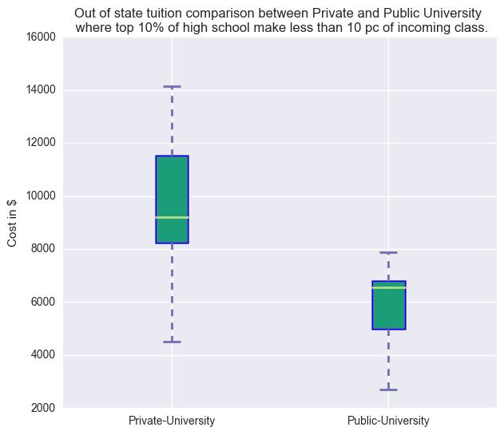

```python
# Code from http://blog.bharatbhole.com/creating-boxplots-with-matplotlib/
## combine these different collections into a list
data_to_plot = [Private_School_Cost, Public_School_Cost]
# Create a figure instance
fig = plt.figure(1, figsize=(7, 6))

# Create an axes instance
ax = fig.add_subplot(111)

# Create the boxplot
bp = ax.boxplot(data_to_plot)

fig.savefig('fig1.png', bbox_inches='tight')

## add patch_artist=True option to ax.boxplot()
## to get fill color
bp = ax.boxplot(data_to_plot, patch_artist=True)

## change outline color, fill color and linewidth of the boxes
for box in bp['boxes']:
    # change outline color
    box.set( color='#7570b3', linewidth=2)
    # change fill color
    box.set( facecolor = '#1b9e77' )

## change color and linewidth of the whiskers
for whisker in bp['whiskers']:
    whisker.set(color='#7570b3', linewidth=2)

## change color and linewidth of the caps
for cap in bp['caps']:
    cap.set(color='#7570b3', linewidth=2)

## change color and linewidth of the medians
for median in bp['medians']:
    median.set(color='#b2df8a', linewidth=2)

## change the style of fliers and their fill
for flier in bp['fliers']:
    flier.set(marker='o', color='#e7298a', alpha=0.5)

## Custom x-axis labels
ax.set_xticklabels(['Private-University', 'Public-University'])
ax.set_ylabel( "Cost in $")
ax.set_title( "Out of state tuition comparison between Private and Public University \n where top 10% of high school make less than 10 pc of incoming class.")
```

*Distribution of Faculty with terminal degree PhD for private and public university*

**University offering at least 4 year or higher degree**

```python
#Private University
Private_count_90 = 0
Private_count_70 = 0
Private_count_50 = 0
Private_count_30 = 0
Private_phd_count = 0


for each in data.index:
    if (data['PhD'][each] >= 90 and data['Private'][each] == 'Private'):
        Private_count_90 = Private_count_90 +1

    elif (data['PhD'][each]>70 and data['PhD'][each] <90 and data['Private'][each] == 'Private'):
        Private_count_70= Private_count_70+1

    elif (data['PhD'][each] > 50 and data['PhD'][each] <70 and data['Private'][each] == 'Private'):
        Private_count_50 = Private_count_50+1

    elif (data['PhD'][each] > 30 and data['PhD'][each] <50 and data['Private'][each] == 'Private'):
        Private_count_30 = Private_count_30+1

Private_phd_count  =  Private_count_90 + Private_count_70 + Private_count_50 +Private_count_30

Private_count_90 = (Private_count_90/Private_phd_count)*100
Private_count_70 = (Private_count_70/Private_phd_count)*100
Private_count_50 = (Private_count_50/Private_phd_count)*100
Private_count_30 = (Private_count_30/Private_phd_count)*100
```

```python
#Public University
Public_count_90 = 0
Public_count_70 = 0
Public_count_50 = 0
Public_count_30 = 0
Public_phd_count = 0

for each in data.index:
    if (data['PhD'][each] >= 90 and data['Private'][each] == 'Public'):
        Public_count_90 = Public_count_90+1

    elif (data['PhD'][each]>70 and data['PhD'][each] <90 and data['Private'][each] == 'Public'):
        Public_count_70 = Public_count_70+1

    elif (data['PhD'][each] > 50 and data['PhD'][each] <70 and data['Private'][each] == 'Public'):
        Public_count_50 = Public_count_50+1

    elif (data['PhD'][each] > 30 and data['PhD'][each] <50 and data['Private'][each] == 'Public'):
        Public_count_30= Public_count_30+1

Public_phd_count = Public_count_90 +Public_count_70+Public_count_50+Public_count_30

Public_count_90 = (Public_count_90/Public_phd_count)*100
Public_count_70 = (Public_count_70/Public_phd_count)*100
Public_count_50 = (Public_count_50/Public_phd_count)*100
Public_count_30 = (Public_count_30/Public_phd_count)*100
```

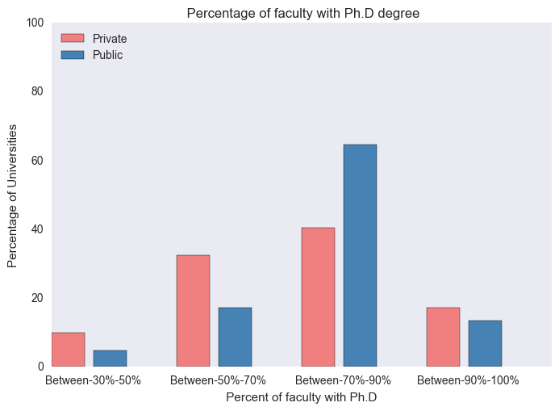

```python
# Defines the sizes of the axes
plt.axis([0,12, 0,100])

p1 = plt.Rectangle((0, 0), 0.1, 0.1, fc="lightcoral")
p2 = plt.Rectangle((0, 0), 0.1, 0.1, fc="steelblue")

plt.legend((p1, p2), ('Private','Public'), loc='upper left')

# Defines labels for each group
labels = ['' , 'Between-30%-50%',  '',  'Between-50%-70%',  '',  'Between-70%-90%',  '' ,  'Between-90%-100%']

# Creates discrete values for x co-ordinates (widths of the bars)
x = np.array([0,1,3,4,6,7,9,10])

# Defines some random set of values for y (heights of the bars)
y = np.array([Private_count_30,Public_count_30,Private_count_50,Public_count_50, Private_count_70, Public_count_70,Private_count_90, Public_count_90])

# Replaces the names in the x-axis with labels
plt.xticks(x, labels)

# Creates the bar chart
plt.bar(left = x, height=y, color=['lightcoral', 'steelblue'])

plt.grid(which='both')
plt.ylabel('Percentage of Universities')
plt.xlabel(' Percent of faculty with Ph.D ')
plt.title(" Percentage of faculty with Ph.D degree")

plt.show()
```

*Graduation rates of Private and public university with acceptance rater > 80%*

**University offering at least 4 year or higher degree**

```python
Private_Graduation_Rate =[]
Public_Graduation_Rate = []

for each in data.index:
    if (data['Acceptance_Percent'][each]> 80 and data['Private'][each] == 'Private'):
        Private_Graduation_Rate.append(data['Grad.Rate'][each])
    elif (data['Acceptance_Percent'][each]> 80 and data['Private'][each] == 'Public'):
        Public_Graduation_Rate.append(data['Grad.Rate'][each])
```

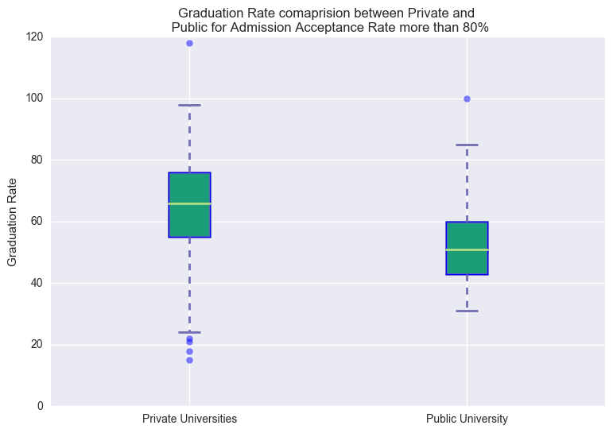

```python
# Code from http://blog.bharatbhole.com/creating-boxplots-with-matplotlib/
## combine these different collections into a list
data_to_plot = [Private_Graduation_Rate, Public_Graduation_Rate]
# Create a figure instance
fig = plt.figure(1, figsize=(9, 6))

# Create an axes instance
ax = fig.add_subplot(111)

# Create the boxplot
bp = ax.boxplot(data_to_plot)

fig.savefig('fig1.png', bbox_inches='tight')

## add patch_artist=True option to ax.boxplot()
## to get fill color
bp = ax.boxplot(data_to_plot, patch_artist=True)

## change outline color, fill color and linewidth of the boxes
for box in bp['boxes']:
    # change outline color
    box.set( color='#7570b3', linewidth=2)
    # change fill color
    box.set( facecolor = '#1b9e77' )

## change color and linewidth of the whiskers
for whisker in bp['whiskers']:
    whisker.set(color='#7570b3', linewidth=2)

## change color and linewidth of the caps
for cap in bp['caps']:
    cap.set(color='#7570b3', linewidth=2)

## change color and linewidth of the medians
for median in bp['medians']:
    median.set(color='#b2df8a', linewidth=2)

## change the style of fliers and their fill
for flier in bp['fliers']:
    flier.set(marker='o', color='#e7298a', alpha=0.5)

## Custom x-axis labels
ax.set_xticklabels(['Private Universities', 'Public University'])
ax.set_ylabel( "Graduation Rate")
ax.set_title( "Graduation Rate comaprision between Private and \n Public for Admission Acceptance Rate more than 80%")
```

**University offering at least 4 year or higher degree**

```python
Private_Graduation_Rate =[]
Public_Graduation_Rate = []

for each in data.index:
    if (data['Acceptance_Percent'][each]< 40 and data['Private'][each] == 'Private'):
        Private_Graduation_Rate.append(data['Grad.Rate'][each])
    elif (data['Acceptance_Percent'][each]< 40 and data['Private'][each] == 'Public'):
        Public_Graduation_Rate.append(data['Grad.Rate'][each])
```

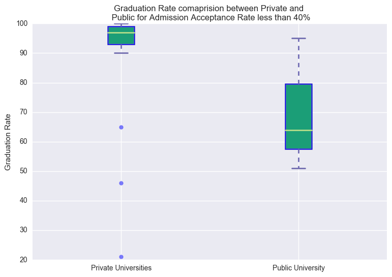

```python
# Code from http://blog.bharatbhole.com/creating-boxplots-with-matplotlib/
## combine these different collections into a list
data_to_plot = [Private_Graduation_Rate, Public_Graduation_Rate]
# Create a figure instance
fig = plt.figure(1, figsize=(9, 6))

# Create an axes instance
ax = fig.add_subplot(111)

# Create the boxplot
bp = ax.boxplot(data_to_plot)

fig.savefig('fig1.png', bbox_inches='tight')

## add patch_artist=True option to ax.boxplot()
## to get fill color
bp = ax.boxplot(data_to_plot, patch_artist=True)

## change outline color, fill color and linewidth of the boxes
for box in bp['boxes']:
    # change outline color
    box.set( color='#7570b3', linewidth=2)
    # change fill color
    box.set( facecolor = '#1b9e77' )

## change color and linewidth of the whiskers
for whisker in bp['whiskers']:
    whisker.set(color='#7570b3', linewidth=2)

## change color and linewidth of the caps
for cap in bp['caps']:
    cap.set(color='#7570b3', linewidth=2)

## change color and linewidth of the medians
for median in bp['medians']:
    median.set(color='#b2df8a', linewidth=2)

## change the style of fliers and their fill
for flier in bp['fliers']:
    flier.set(marker='o', color='#e7298a', alpha=0.5)

## Custom x-axis labels
ax.set_xticklabels(['Private Universities', 'Public University'])
ax.set_ylabel( "Graduation Rate")
ax.set_title( "Graduation Rate comaprision between Private and \n Public for Admission Acceptance Rate less than 40%")
```

Graduation rate for private univeristies are higher than public universities irrespective of the admission acceptance rates.

*Maximum number of S.F ratio needed to obtain a 90% graduation rate.*

**University offering at least 4 year or higher degree**

```python
maximum_sf_ratio = []
for each in data.index:
    if (data['Grad.Rate'][each]> 90):
        maximum_sf_ratio.append(data['S.F.Ratio'][each])
max(maximum_sf_ratio)
```

```
24.100000000000001
```

*Number of Public/Private universities in NY, CA,OH with graduation rate >50% and out of state tuition <20,000.* **University offering at least 4 year or higher degree**

```python
df = pd.read_csv('postscndryunivsrvy2013dirinfo.csv')
df.info()
```

```
<class 'pandas.core.frame.DataFrame'>
RangeIndex: 7769 entries, 0 to 7768
Data columns (total 66 columns):
UNITID      7769 non-null int64
INSTNM      7769 non-null object
ADDR        7769 non-null object
CITY        7769 non-null object
STABBR      7769 non-null object
ZIP         7769 non-null object
FIPS        7769 non-null int64
OBEREG      7769 non-null int64
CHFNM       7769 non-null object
CHFTITLE    7769 non-null object
GENTELE     7769 non-null object
FAXTELE     7769 non-null object
EIN         7769 non-null int64
OPEID       7769 non-null int64
OPEFLAG     7769 non-null int64
WEBADDR     7769 non-null object
ADMINURL    7769 non-null object
FAIDURL     7769 non-null object
APPLURL     7769 non-null object
NPRICURL    7769 non-null object
SECTOR      7769 non-null int64
ICLEVEL     7769 non-null int64
CONTROL     7769 non-null int64
HLOFFER     7769 non-null int64
UGOFFER     7769 non-null int64
GROFFER     7769 non-null int64
HDEGOFR1    7769 non-null int64
DEGGRANT    7769 non-null int64
HBCU        7769 non-null int64
HOSPITAL    7769 non-null int64
MEDICAL     7769 non-null int64
TRIBAL      7769 non-null int64
LOCALE      7769 non-null int64
OPENPUBL    7769 non-null int64
ACT         7769 non-null object
NEWID       7769 non-null int64
DEATHYR     7769 non-null int64
```

[output cut: 16 more lines]

```
INSTSIZE    7769 non-null int64
CBSA        7769 non-null int64
CBSATYPE    7769 non-null int64
CSA         7769 non-null int64
NECTA       7769 non-null int64
F1SYSTYP    7769 non-null int64
F1SYSNAM    7769 non-null object
F1SYSCOD    7769 non-null int64
COUNTYCD    7769 non-null int64
COUNTYNM    7769 non-null object
CNGDSTCD    7769 non-null int64
LONGITUD    7769 non-null float64
LATITUDE    7769 non-null float64
dtypes: float64(2), int64(45), object(19)
memory usage: 3.9+ MB
```

```python
data=data.rename(columns = {'University Name':'University_Name'})
```

```python
is_uni_in = data.University_Name.isin(df.INSTNM)
data['is_uni_in'] = is_uni_in
```

```python
subset = data[data['is_uni_in'] == True]
```

```python
state=[]

for each in subset.index:
    for position in df.index:
        if(subset['University_Name'][each]==df['INSTNM'][position]):
            state.append(df['STABBR'][position])
```

```python
updated_state = state[:494]
subset['updated_state'] = updated_state
```

```python
subset.head()
```

|  | University_Name | Private | Apps | Accept | Enroll | Top10perc | Top25perc | F.Undergrad | P.Undergrad | Outstate | ... | Personal | PhD | Terminal | S.F.Ratio | perc.alumni | Expend | Grad.Rate | Acceptance_Percent | is_uni_in | updated_state |
| --- | --- | --- | --- | --- | --- | --- | --- | --- | --- | --- | --- | --- | --- | --- | --- | --- | --- | --- | --- | --- | --- |
| 0 | Abilene Christian University | Private | 1660 | 1232 | 721 | 23 | 52 | 2885 | 537 | 7440 | ... | 2200 | 70 | 78 | 18.1 | 12 | 7041 | 60 | 74.216867 | True | TX |
| 1 | Adelphi University | Private | 2186 | 1924 | 512 | 16 | 29 | 2683 | 1227 | 12280 | ... | 1500 | 29 | 30 | 12.2 | 16 | 10527 | 56 | 88.014639 | True | NY |
| 2 | Adrian College | Private | 1428 | 1097 | 336 | 22 | 50 | 1036 | 99 | 11250 | ... | 1165 | 53 | 66 | 12.9 | 30 | 8735 | 54 | 76.820728 | True | MI |
| 3 | Agnes Scott College | Private | 417 | 349 | 137 | 60 | 89 | 510 | 63 | 12960 | ... | 875 | 92 | 97 | 7.7 | 37 | 19016 | 59 | 83.693046 | True | GA |
| 4 | Alaska Pacific University | Private | 193 | 146 | 55 | 16 | 44 | 249 | 869 | 7560 | ... | 1500 | 76 | 72 | 11.9 | 2 | 10922 | 15 | 75.647668 | True | AK |

5 rows × 22 columns

In California

```python
private_count = 0
public_count = 0

for each in subset.index:
    if (subset['Grad.Rate'][each]> 50 and subset['Outstate'][each] < 20000 and subset['updated_state'][each]== 'CA' and subset['Private'][each]== 'Private' ):
        private_count = private_count+1
    elif (subset['Grad.Rate'][each]> 50 and subset['Outstate'][each] < 20000 and subset['updated_state'][each]== 'CA' and subset['Private'][each]== 'Public' ):
        public_count = public_count+1
```

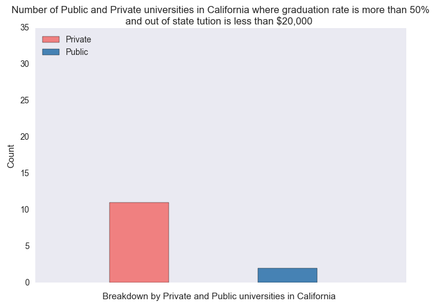

```python
# Defines the sizes of the axes
plt.axis([0,5, 0,35])

p1 = plt.Rectangle((0, 0), 0.1, 0.1, fc="lightcoral")
p2 = plt.Rectangle((0, 0), 0.1, 0.1, fc="steelblue")

plt.legend((p1, p2), ('Private','Public'), loc='upper left')

# Defines labels for each group
labels = []

# Creates discrete values for x co-ordinates (widths of the bars)
x = np.array([1,3])

# Defines some random set of values for y (heights of the bars)
y = np.array([private_count,public_count])

# Replaces the names in the x-axis with labels
plt.xticks(x, labels)

# Creates the bar chart
plt.bar(left = x, height=y, color=['lightcoral', 'steelblue'])

plt.grid(which='both')
plt.ylabel('Count')
plt.xlabel(' Breakdown by Private and Public universities in California  ')
plt.title("  Number of Public and Private universities in California where graduation rate is more than 50%  \n and out of state tution is less than $20,000  ")

plt.show()
```

```python
private_count = 0
public_count = 0

for each in subset.index:
    if (subset['Grad.Rate'][each]> 50 and subset['Outstate'][each] < 20000 and subset['updated_state'][each]== 'CA' and subset['Private'][each]== 'Private' ):
        private_count = private_count+1
    elif (subset['Grad.Rate'][each]> 50 and subset['Outstate'][each] < 20000 and subset['updated_state'][each]== 'CA' and subset['Private'][each]== 'Public' ):
        public_count = public_count+1
```

In NY

```python
private_count = 0
public_count = 0

for each in subset.index:
    if (subset['Grad.Rate'][each]> 50 and subset['Outstate'][each] < 20000 and subset['updated_state'][each]== 'NY' and subset['Private'][each]== 'Private' ):
        private_count = private_count+1
    elif (subset['Grad.Rate'][each]> 50 and subset['Outstate'][each] < 20000 and subset['updated_state'][each]== 'NY' and subset['Private'][each]== 'Public' ):
        public_count = public_count+1
```

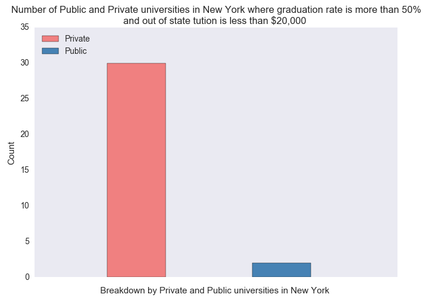

```python
# Defines the sizes of the axes
plt.axis([0,5, 0,35])

p1 = plt.Rectangle((0, 0), 0.1, 0.1, fc="lightcoral")
p2 = plt.Rectangle((0, 0), 0.1, 0.1, fc="steelblue")

plt.legend((p1, p2), ('Private','Public'), loc='upper left')

# Defines labels for each group
labels = []

# Creates discrete values for x co-ordinates (widths of the bars)
x = np.array([1,3])

# Defines some random set of values for y (heights of the bars)
y = np.array([private_count,public_count])

# Replaces the names in the x-axis with labels
plt.xticks(x, labels)

# Creates the bar chart
plt.bar(left = x, height=y, color=['lightcoral', 'steelblue'])

plt.grid(which='both')
plt.ylabel('Count')
plt.xlabel(' Breakdown by Private and Public universities in New York  ')
plt.title("  Number of Public and Private universities in New York where graduation rate is more than 50%  \n and out of state tution is less than $20,000  ")

plt.show()
```

In Texas

```python
private_count = 0
public_count = 0

for each in subset.index:
    if (subset['Grad.Rate'][each]> 50 and subset['Outstate'][each] < 20000 and subset['updated_state'][each]== 'TX' and subset['Private'][each]== 'Private' ):
        private_count = private_count+1
    elif (subset['Grad.Rate'][each]> 50 and subset['Outstate'][each] < 20000 and subset['updated_state'][each]== 'TX' and subset['Private'][each]== 'Public' ):
        public_count = public_count+1
```

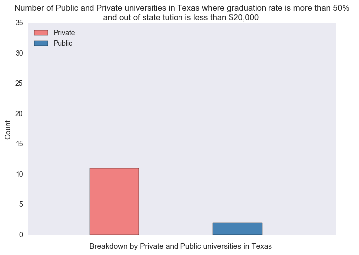

```python
# Defines the sizes of the axes
plt.axis([0,5, 0,35])

p1 = plt.Rectangle((0, 0), 0.1, 0.1, fc="lightcoral")
p2 = plt.Rectangle((0, 0), 0.1, 0.1, fc="steelblue")

plt.legend((p1, p2), ('Private','Public'), loc='upper left')

# Defines labels for each group
labels = []

# Creates discrete values for x co-ordinates (widths of the bars)
x = np.array([1,3])

# Defines some random set of values for y (heights of the bars)
y = np.array([private_count,public_count])

# Replaces the names in the x-axis with labels
plt.xticks(x, labels)

# Creates the bar chart
plt.bar(left = x, height=y, color=['lightcoral', 'steelblue'])

plt.grid(which='both')
plt.ylabel('Count')
plt.xlabel(' Breakdown by Private and Public universities in Texas  ')
plt.title("  Number of Public and Private universities in Texas where graduation rate is more than 50%  \n and out of state tution is less than $20,000  ")

plt.show()
```

In Ohio

```python
private_count = 0
public_count = 0

for each in subset.index:
    if (subset['Grad.Rate'][each]> 50 and subset['Outstate'][each] < 20000 and subset['updated_state'][each]== 'OH' and subset['Private'][each]== 'Private' ):
        private_count = private_count+1
    elif (subset['Grad.Rate'][each]> 50 and subset['Outstate'][each] < 20000 and subset['updated_state'][each]== 'OH' and subset['Private'][each]== 'Public' ):
        public_count = public_count+1
```

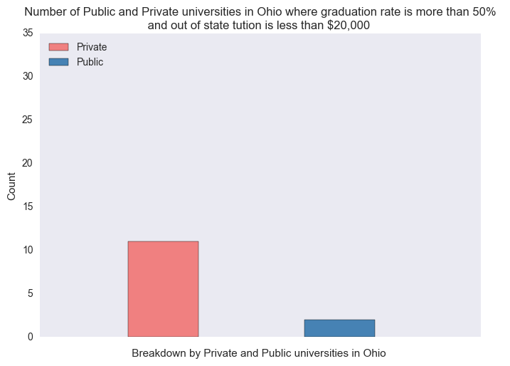

```python
# Defines the sizes of the axes
plt.axis([0,5, 0,35])

p1 = plt.Rectangle((0, 0), 0.1, 0.1, fc="lightcoral")
p2 = plt.Rectangle((0, 0), 0.1, 0.1, fc="steelblue")

plt.legend((p1, p2), ('Private','Public'), loc='upper left')

# Defines labels for each group
labels = []

# Creates discrete values for x co-ordinates (widths of the bars)
x = np.array([1,3])

# Defines some random set of values for y (heights of the bars)
y = np.array([private_count,public_count])

# Replaces the names in the x-axis with labels
plt.xticks(x, labels)

# Creates the bar chart
plt.bar(left = x, height=y, color=['lightcoral', 'steelblue'])

plt.grid(which='both')
plt.ylabel('Count')
plt.xlabel(' Breakdown by Private and Public universities in Ohio  ')
plt.title("  Number of Public and Private universities in Ohio where graduation rate is more than 50%  \n and out of state tution is less than $20,000  ")

plt.show()
```

```python
test_df  = pd.DataFrame(state,columns=['states'])
freq_state =test_df['states'].value_counts()
print freq_state
```

[output not shown]

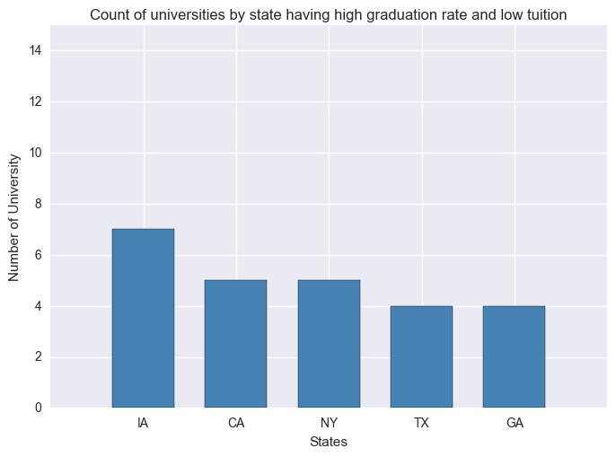

```python
weed = [7, 5, 5, 4,4]
width = 1/1.5
x= range(len(weed))

figure, axes = plt.subplots()

axes.bar(x, weed, width, color="steelblue", align="center")
axes.set_xticks([0, 1, 2, 3, 4,5])
axes.set_xlabel('States')
axes.set_xticklabels(["IA", "CA", "NY", "TX","GA"])
axes.yaxis.grid( b=True, which="major")
axes.set_ylabel('Number of University')
axes.set_ylim((0, 15))
axes.set_title('Count of universities by state having high graduation rate and low tuition')

plt.show()
```

Iowa has 7 universities that has graduation rate more than 80 perecent while maintaining a tuition fee of less than 8000$ a year. If you are considering going into a quality 4 year college program and are low on funds. These 5 states should be top of your priority list.

*Private vs Public university based on the the percentage of alumni making donations.*

**University offering at least 4 year or higher degree**

```python
#Private University
Private_alumni_10 = 0
Private_alumni_20 = 0
Private_alumni_30 = 0
Private_alumni_40 = 0
Total_private_university = 0

for each in data.index:
    if (data['perc.alumni'][each] > 0 and data['perc.alumni'][each] < 10  and data['Private'][each] == 'Private'):
        Private_alumni_10 = Private_alumni_10 +1

    elif (data['perc.alumni'][each]>10 and data['perc.alumni'][each] <20 and data['Private'][each] == 'Private'):
        Private_alumni_20= Private_alumni_20+1

    elif (data['perc.alumni'][each] > 30 and data['perc.alumni'][each] <40 and data['Private'][each] == 'Private'):
        Private_alumni_30 = Private_alumni_30+1

    elif (data['PhD'][each] > 40  and data['Private'][each] == 'Private'):
        Private_alumni_40 = Private_alumni_40+1



Total_private_university  = Private_alumni_10 + Private_alumni_20 + Private_alumni_30 + Private_alumni_40

Private_alumni_10 =  (Private_alumni_10/Total_private_university) * 100
Private_alumni_20 =  (Private_alumni_20/Total_private_university) *100
Private_alumni_30 =  (Private_alumni_30/Total_private_university)*100
Private_alumni_40 =  (Private_alumni_40/ Total_private_university)*100
```

**Public University**

```python
#Public University
Public_alumni_10 = 0
Public_alumni_20 = 0
Public_alumni_30 = 0
Public_alumni_40 = 0
Total_public_university = 0

for each in data.index:
    if (data['perc.alumni'][each] > 0 and data['perc.alumni'][each] < 10  and data['Private'][each] == 'Public'):
        Public_alumni_10 = Public_alumni_10 +1

    elif (data['perc.alumni'][each]>10 and data['perc.alumni'][each] <20 and data['Private'][each] == 'Public'):
        Public_alumni_20= Public_alumni_20+1

    elif (data['perc.alumni'][each] > 30 and data['perc.alumni'][each] <40 and data['Private'][each] == 'Public'):
        Public_alumni_30 = Public_alumni_30+1

    elif (data['PhD'][each] > 40  and data['Private'][each] == 'Public'):
        Public_alumni_40 = Public_alumni_40+1

Total_public_university  = Public_alumni_10 + Public_alumni_20 + Public_alumni_30 + Public_alumni_40

Public_alumni_10 = (Public_alumni_10/Total_public_university) * 100
Public_alumni_20 = (Public_alumni_10/Total_public_university) * 100
Public_alumni_30 = (Public_alumni_10/Total_public_university) * 100
Public_alumni_40 = (Public_alumni_10/Total_public_university) * 100
```

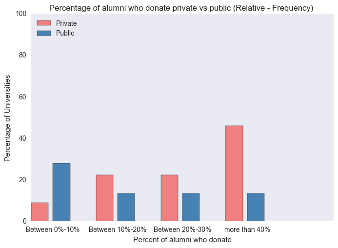

```python
# Defines the sizes of the axes
plt.axis([0,14, 0,100])

p1 = plt.Rectangle((0, 0), 0.1, 0.1, fc="lightcoral")
p2 = plt.Rectangle((0, 0), 0.1, 0.1, fc="steelblue")

plt.legend((p1, p2), ('Private','Public'), loc='upper left')

# Defines labels for each group
labels = ['' , ' Between 0%-10% ',  '',  'Between 10%-20%',  '',  'Between 20%-30%',  '' ,  'more than 40%']

# Creates discrete values for x co-ordinates (widths of the bars)
x = np.array([0,1,3,4,6,7,9,10])

# Defines some random set of values for y (heights of the bars)
y = np.array([Private_alumni_10,Public_alumni_10,Private_alumni_20,Public_alumni_20, Private_alumni_30, Public_alumni_30,Private_alumni_40, Public_alumni_40])

# Replaces the names in the x-axis with labels
plt.xticks(x, labels)

# Creates the bar chart
plt.bar(left = x, height=y, color=['lightcoral', 'steelblue'])

plt.grid(which='both')
plt.ylabel('Percentage of Universities')
plt.xlabel(' Percent of alumni who donate ')
plt.title("Percentage of alumni who donate private vs public (Relative - Frequency) ")

plt.show()
```

Across all classifications, barring one private universities alumni has a higher proportion of donating to their school.

*How many application to universities, on an average does each student make for a 4 year university?*

```python
total_apps = data['Apps'].sum()
total_enrol = data['Enroll'].sum()
application_per_applicant  = total_apps/total_enrol
print application_per_applicant
```

```
3.84838764502
```

*Breakdown of number of university in the USA classification by Program Length. (Public vs Private)*

```python
df.CONTROL.value_counts()
```

```
 3    3687
 1    2108
 2    1969
-3       5
Name: CONTROL, dtype: int64
```

2 and 3 represents a private entity controlling the university and 1 is a public university

```python
df. ICLEVEL.value_counts()
```

```
 1    3299
 2    2333
 3    2132
-3       5
Name: ICLEVEL, dtype: int64
```

```python
df['CONTROL'].replace(1,'Public',inplace=True)
df['CONTROL'].replace(2,'Private',inplace=True)
df['CONTROL'].replace(3,'Private',inplace=True)
df['CONTROL'].replace(-3,np.nan,inplace=True)
```

```python
df['ICLEVEL'].replace(1,'4_Year',inplace=True)
df['ICLEVEL'].replace(2,'2_to_4_Year',inplace=True)
df['ICLEVEL'].replace(3,'Less_than_4_Year',inplace=True)
df['ICLEVEL'].replace(-3,np.nan,inplace=True)
```

```python
df['LOCALE'].replace(11,'City',inplace=True)
df['LOCALE'].replace(12,'City',inplace=True)
df['LOCALE'].replace(13,'City',inplace=True)
df['LOCALE'].replace(21,'Suburbs',inplace=True)
df['LOCALE'].replace(22,'Suburbs',inplace=True)
df['LOCALE'].replace(23,'Suburbs',inplace=True)
df['LOCALE'].replace(31,'Town',inplace=True)
df['LOCALE'].replace(32,'Town',inplace=True)
df['LOCALE'].replace(33,'Town',inplace=True)
df['LOCALE'].replace(41,'Rural',inplace=True)
df['LOCALE'].replace(42,"Rural",inplace=True)
df['LOCALE'].replace(43,'Rural',inplace=True)
df['LOCALE'].replace(-3,np.nan,inplace=True)
```

```python
updated_df = df.dropna()
```

```python
#Private University
Private_4_yr = 0
Private_2_yr = 0
Private_0_yr = 0


for each in updated_df.index:
    if (updated_df['ICLEVEL'][each]== '4_Year' and  updated_df['CONTROL'][each] == 'Private'):
        Private_4_yr = Private_4_yr +1

    elif (updated_df['ICLEVEL'][each]== '2_to_4_Year' and updated_df['CONTROL'][each] == 'Private'):
        Private_2_yr= Private_2_yr+1

    elif (updated_df['ICLEVEL'][each]== 'Less_than_4_Year' and updated_df['CONTROL'][each] == 'Private'):
        Private_0_yr = Private_0_yr+1
```

```python
#Public University
Public_4_yr = 0
Public_2_yr = 0
Public_0_yr = 0


for each in updated_df.index:
    if (updated_df['ICLEVEL'][each]== '4_Year' and  updated_df['CONTROL'][each] == 'Public'):
        Public_4_yr = Public_4_yr +1

    elif (updated_df['ICLEVEL'][each]== '2_to_4_Year' and updated_df['CONTROL'][each] == 'Public'):
        Public_2_yr= Public_2_yr+1

    elif (updated_df['ICLEVEL'][each]== 'Less_than_4_Year' and updated_df['CONTROL'][each] == 'Public'):
        Public_0_yr = Public_0_yr+1
```

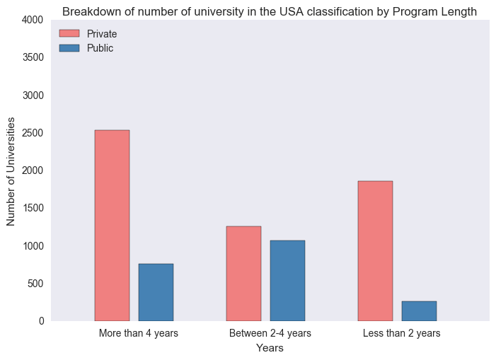

```python
# Defines the sizes of the axes
plt.axis([0,10, 0,4000])

p1 = plt.Rectangle((0, 0), 0.1, 0.1, fc="lightcoral")
p2 = plt.Rectangle((0, 0), 0.1, 0.1, fc="steelblue")

plt.legend((p1, p2), ('Private','Public'), loc='upper left')

# Defines labels for each group
labels = ['' , ' More than 4 years ',  '',  'Between 2-4 years',  '',  'Less than 2 years']

# Creates discrete values for x co-ordinates (widths of the bars)
x = np.array([1,2,4,5,7,8])

# Defines some random set of values for y (heights of the bars)
y = np.array([Private_4_yr,Public_4_yr,Private_2_yr,Public_2_yr, Private_0_yr, Public_0_yr])

# Replaces the names in the x-axis with labels
plt.xticks(x, labels)

# Creates the bar chart
plt.bar(left = x, height=y, color=['lightcoral', 'steelblue'])

plt.grid(which='both')
plt.ylabel('Number of Universities')
plt.xlabel('Years')
plt.title("Breakdown of number of university in the USA classification by Program Length")

plt.show()
```

*Breakdown of number of university in the USA classification by Location. (Public vs Private)*

```python
updated_df.LOCALE.value_counts()
```

```
City       3799
Suburbs    2419
Town        953
Rural       590
Name: LOCALE, dtype: int64
```

```python
#Private University
Private_location_city = 0
Private_location_sub = 0
Private_location_town = 0
Private_location_rural = 0


for each in updated_df.index:
    if (updated_df['LOCALE'][each]== 'City' and  updated_df['CONTROL'][each] == 'Private'):
        Private_location_city = Private_location_city +1

    elif (updated_df['LOCALE'][each]== 'Suburbs' and updated_df['CONTROL'][each] == 'Private'):
        Private_location_sub= Private_location_sub+1

    elif (updated_df['LOCALE'][each]== 'Town' and updated_df['CONTROL'][each] == 'Private'):
        Private_location_town = Private_location_town+1

    elif (updated_df['LOCALE'][each]== 'Rural' and updated_df['CONTROL'][each] == 'Private'):
        Private_location_rural = Private_location_rural+1
```

```python
#Private University
Public_location_city = 0
Public_location_sub = 0
Public_location_town = 0
Public_location_rural = 0


for each in updated_df.index:
    if (updated_df['LOCALE'][each]== 'City' and  updated_df['CONTROL'][each] == 'Public'):
        Public_location_city = Public_location_city +1

    elif (updated_df['LOCALE'][each]== 'Suburbs' and updated_df['CONTROL'][each] == 'Public'):
        Public_location_sub= Public_location_sub+1

    elif (updated_df['LOCALE'][each]== 'Town' and updated_df['CONTROL'][each] == 'Public'):
        Public_location_town = Public_location_town+1

    elif (updated_df['LOCALE'][each]== 'Rural' and updated_df['CONTROL'][each] == 'Public'):
        Public_location_rural = Public_location_rural+1
```

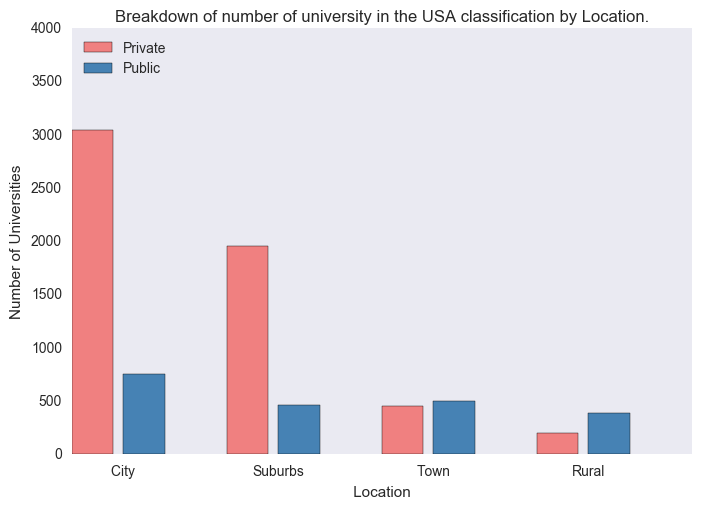

```python
# Defines the sizes of the axes
plt.axis([0,12, 0, 4000])

p1 = plt.Rectangle((0, 0), 0.1, 0.1, fc="lightcoral")
p2 = plt.Rectangle((0, 0), 0.1, 0.1, fc="steelblue")

plt.legend((p1, p2), ('Private','Public'), loc='upper left')

# Defines labels for each group
labels = ['' , ' City ',  '',  'Suburbs',  '',  'Town',  '' ,  'Rural']

# Creates discrete values for x co-ordinates (widths of the bars)
x = np.array([0,1,3,4,6,7,9,10])

# Defines some random set of values for y (heights of the bars)
y = np.array([Private_location_city,Public_location_city,
              Private_location_sub,Public_location_sub,
              Private_location_town, Public_location_town,
              Private_location_rural, Public_location_rural])

# Replaces the names in the x-axis with labels
plt.xticks(x, labels)

# Creates the bar chart
plt.bar(left = x, height=y, color=['lightcoral', 'steelblue'])

plt.grid(which='both')
plt.ylabel('Number of Universities')
plt.xlabel(' Location ')
plt.title("Breakdown of number of university in the USA classification by Location.")

plt.show()
```

**Relation between book cost and faculty who have Ph.d**

```python
Private_book_Rate =[]
Public_book_Rate = []

for each in data.index:
    if (data['PhD'][each] >70 and data['Private'][each] == 'Private'):
        Private_book_Rate.append(data['Books'][each])
    elif (data['PhD'][each] >70 and data['Private'][each] == 'Public'):
        Public_book_Rate.append(data['Books'][each])
```

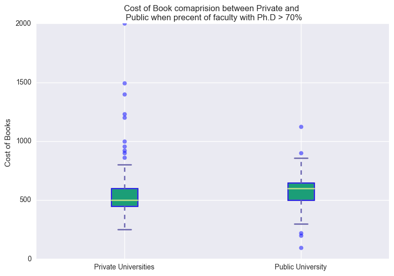

```python
# Code from http://blog.bharatbhole.com/creating-boxplots-with-matplotlib/
## combine these different collections into a list
data_to_plot = [Private_book_Rate, Public_book_Rate]
# Create a figure instance
fig = plt.figure(1, figsize=(9, 6))

# Create an axes instance
ax = fig.add_subplot(111)

# Create the boxplot
bp = ax.boxplot(data_to_plot)

fig.savefig('fig1.png', bbox_inches='tight')

## add patch_artist=True option to ax.boxplot()
## to get fill color
bp = ax.boxplot(data_to_plot, patch_artist=True)

## change outline color, fill color and linewidth of the boxes
for box in bp['boxes']:
    # change outline color
    box.set( color='#7570b3', linewidth=2)
    # change fill color
    box.set( facecolor = '#1b9e77' )

## change color and linewidth of the whiskers
for whisker in bp['whiskers']:
    whisker.set(color='#7570b3', linewidth=2)

## change color and linewidth of the caps
for cap in bp['caps']:
    cap.set(color='#7570b3', linewidth=2)

## change color and linewidth of the medians
for median in bp['medians']:
    median.set(color='#b2df8a', linewidth=2)

## change the style of fliers and their fill
for flier in bp['fliers']:
    flier.set(marker='o', color='#e7298a', alpha=0.5)

## Custom x-axis labels
ax.set_xticklabels(['Private Universities', 'Public University'])
ax.set_ylabel( "Cost of Books ")
ax.set_title( "Cost of Book comaprision between Private and \n Public when precent of faculty with Ph.D > 70%")
```

Expend

```python
Private_expend_Rate =[]
Public_expend_Rate = []

for each in data.index:
    if ( data['Private'][each] == 'Private'):
        Private_expend_Rate.append(data['Expend'][each])
    elif (data['Private'][each] == 'Public'):
        Public_expend_Rate.append(data['Expend'][each])
```

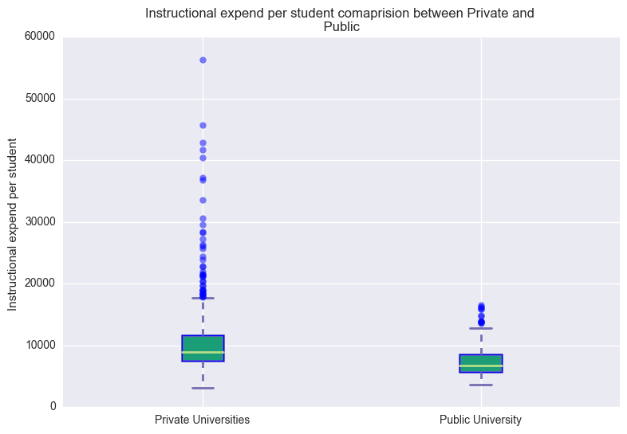

```python
# Code from http://blog.bharatbhole.com/creating-boxplots-with-matplotlib/
## combine these different collections into a list
data_to_plot = [Private_expend_Rate, Public_expend_Rate]
# Create a figure instance
fig = plt.figure(1, figsize=(9, 6))

# Create an axes instance
ax = fig.add_subplot(111)

# Create the boxplot
bp = ax.boxplot(data_to_plot)

fig.savefig('fig1.png', bbox_inches='tight')

## add patch_artist=True option to ax.boxplot()
## to get fill color
bp = ax.boxplot(data_to_plot, patch_artist=True)

## change outline color, fill color and linewidth of the boxes
for box in bp['boxes']:
    # change outline color
    box.set( color='#7570b3', linewidth=2)
    # change fill color
    box.set( facecolor = '#1b9e77' )

## change color and linewidth of the whiskers
for whisker in bp['whiskers']:
    whisker.set(color='#7570b3', linewidth=2)

## change color and linewidth of the caps
for cap in bp['caps']:
    cap.set(color='#7570b3', linewidth=2)

## change color and linewidth of the medians
for median in bp['medians']:
    median.set(color='#b2df8a', linewidth=2)

## change the style of fliers and their fill
for flier in bp['fliers']:
    flier.set(marker='o', color='#e7298a', alpha=0.5)

## Custom x-axis labels
ax.set_xticklabels(['Private Universities', 'Public University'])
ax.set_ylabel( "Instructional expend per student ")
ax.set_title( "Instructional expend per student comaprision between Private and \n Public ")
```

The story: Universities at a glance: Comparing Private vs Public University?

1) The **length of the program** and the count of university by private snd public.

2) **Where are they located** : Breakdown of number of university in the USA classification by Location.

If one enrol for a 4 year course:

3) Decision point 1: **Percentage of faculty with Ph.D degree private vs public** - Relative Frequency

4) Decision point 2: **Percentage of alumni who donate private vs public** (Relative - Frequency)

5) Decsion point 3 : **Elite vs Non Elite?**

```
5.1) Merits of attending  Elite Uiversity?
```

6) Suggestion -Low on funds and want quality education.? **Top 5 states with highest number of universities with high graduation rate and low out of state tuition.**